## Patronus charm: a contrast of benefactor plant specificity

**Panoche Hills Ecological Reserve**

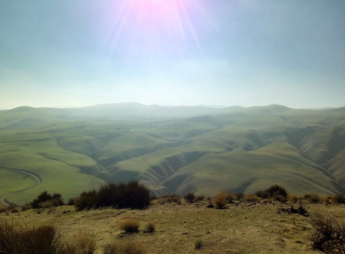

**Mojave National Preserve**

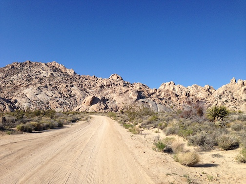

[ecoblender](http://ecoblender.org)

**Precis**  
Deserts globally are subject to significant anthropogenic pressure. Global change, agriculture, energy projects, urbanization, and other ongoing drivers introduce stressors on the resilience of arid and semi-arid ecosystems. The capacity to buffer against these changes in the environment and biodiversity are important considerations for ecosystem functioning and applied decision-making frameworks. Foundation species analyses can be a solution to rapidly assess ecological function for a specific region. A foundation species is defined as species that exerts and promotes a positive set of processes for the network of resident species. Shrubs and cacti in California are both candidate representative functional grouping of plant species that benefit other plants and often animals within a region. Herein, we sampled the effect of shrubs and cacti on other plant species through systematic plant surveys on environmental gradients. The hypothesis tested was that the direct effects of dominant plants lead to facilitation of other plant species and thereby function as buffers to undue change. Colloquially, this can be termed a patronus charm effect within facilitation ecology because regardless of the form of the protector, the species provides a talisman against local loss of function. Gradients are also an important tool that can provide a critical estimate of the relative importance of ecological context within a region.

### Data

Panoche sites = 1.1 is plateau, 1.2 is south, 1.3 is north. The plateau is approx 5 km^2 and sites 1.2 and 1.3 are 1 acre. Extensive manipulative research including shrub removals and mimics done at Panoche site 1.1, the plateau.

Mojave sites = a total of five sites with each on Kelbaker Road corresponding to increasing elevations of 313, 515, 737,951, & 1128m.

**The simplified hypothesis tested is that foundation shrub effects are species specific.** The importance of local gradients are also examined and cursorily framed within larger climate data.

*Ephedra californica* effects are contrasted to those of *Larrea tridentata* in two different desert sites at the upper and lower extents of the San Joaquin Desert Region.  
The cacti species *Cylindropuntia acanthocarpa* is also explored in brief for a presentation at CNPS.

```r
library(tidyverse)
#meta-data in brief for field sampling
metadata <- read_csv("data/meta-data.csv")
knitr::kable(metadata)
```

| attribute | description |
| --- | --- |
| x | x1 - was measured as the longest diameter of the shrub plant |
| x | x2 - was the diameter directly perpendicular to diameter x1 |
| h | h - was measured as the tallest branch with leaves |
| methods | Quadrat sampling was conducted with a 50 cm X 50 cm quadrat construction from white PVC pipe |
| methods | Shrubs for each site were chosen within ten meters of one another in a generally linear pattern |
| methods | Open plots were placed approximately two meters from the shrub exterior |
| methods | Quadrats were placed close to the base of the shrub plant such that it was underneath as much of shrub cover as possible. |
| methods | Two soil cores 5 cm in depth were taken at all shrub/open pairs and place into separate coin envelopes. |
| methods | Shrub cores were taken close to shrub base and open cores were taken in center. |
| # sp | Plant species were delineated during the first sampling event by visually obvious differences |
| total seed mass | mass of seeds/mass of sand |
| 2013 census | 1 = Jan 20, 2 = Feb 20 |
| 2014 census | 3 = Mar 25, 28 |
| 2015 census | March |
| 2016 census | March |
| 2017 census | April |

```r
#effect-size estimates
foundation.rii <- read_csv("data/shrub.rii.contrast.csv")
foundation.rii
```

```
## # A tibble: 840 x 11
##     Year Region  Site Site.name   Rep Microsite    D1    D2     H
##    <int>  <chr> <dbl>     <chr> <int>     <chr> <dbl> <dbl> <dbl>
##  1  2017 Mojave   2.1      MNP1     1     Shrub  1.68  1.62  1.51
##  2  2017 Mojave   2.1      MNP1     2     Shrub  1.51  1.67  1.29
##  3  2017 Mojave   2.1      MNP1     3     Shrub  1.08  1.25  1.55
##  4  2017 Mojave   2.1      MNP1     4     Shrub  1.42  1.72  1.32
##  5  2017 Mojave   2.1      MNP1     5     Shrub  1.64  1.95  1.49
##  6  2017 Mojave   2.1      MNP1     6     Shrub  2.18  2.12  1.40
##  7  2017 Mojave   2.1      MNP1     7     Shrub  1.55  1.51  1.37
##  8  2017 Mojave   2.1      MNP1     8     Shrub  1.81  1.59  1.69
##  9  2017 Mojave   2.1      MNP1     9     Shrub  1.32  1.37  0.75
## 10  2017 Mojave   2.1      MNP1    10     Shrub  1.48  1.42  1.37
## # ... with 830 more rows, and 2 more variables: Abundance <dbl>,
## #   Richness <dbl>
```

```r
foundation.rii <- foundation.rii %>% mutate(Volume = ((D1 + D2)/2)^3*3.14*(1/3))
foundation.rii$Year <- as.character(foundation.rii$Year)
foundation.rii$Site <- as.character(foundation.rii$Site)

#sites for shrub-shrub contrast
sites <- read_csv("data/sites.csv")
sites$Site <- as.character(sites$Site)
sites
```

```
## # A tibble: 8 x 9
##   Site.name  Site            Shrub      Lat      Long Elevation  Aspect
##       <chr> <chr>            <chr>    <dbl>     <dbl>     <int>   <chr>
## 1      PAN1   1.1          Ephedra 36.89880 -121.0294       661 Plateau
## 2      PAN2   1.2          Ephedra 36.82860 -121.0158       611   South
## 3      PAN3   1.3          Ephedra 36.79330 -121.0394       596   North
## 4      MNP1   2.1 Larrea Tridentia 35.25608 -116.0472       313    Flat
## 5      MNP2   2.2 Larrea Tridentia 35.25020 -115.9224       515    Flat
## 6      MNP3   2.3 Larrea Tridentia 35.18428 -115.8600       737    Flat
## 7      MNP4   2.4 Larrea Tridentia 35.15517 -115.7903       951    Flat
## 8      MNP5   2.5 Larrea Tridentia 35.14453 -115.7286      1128   Rocky
## # ... with 2 more variables: Geography <chr>, Directions <chr>
```

```r
#basic climate
#Worldclim
#Bio_1: annual temperature
#Bio_8: temperature in the wettest quarter
#Bio_12: annual precipitation
#Bio_15: precipitation seasonality (CV)
#Bio_16: precipitation wettest quarter

climate <- read_csv("data/shrub.contrast.climate.csv")
climate$Site <- as.character(climate$Site)
```

### Map

[figure not shown]

```r
require(ggmap)
cali <- get_map(location = c(lon = -118, lat = 35), zoom = 7)
#cali <-get_googlemap("california", crop= FALSE, zoom = 10)
p <-ggmap(cali)
p + geom_point(data=sites, aes(x=Long, y=Lat), alpha = 0.5, size = 4) + labs(x ="longitude", y = "latitude")
```

### Climate

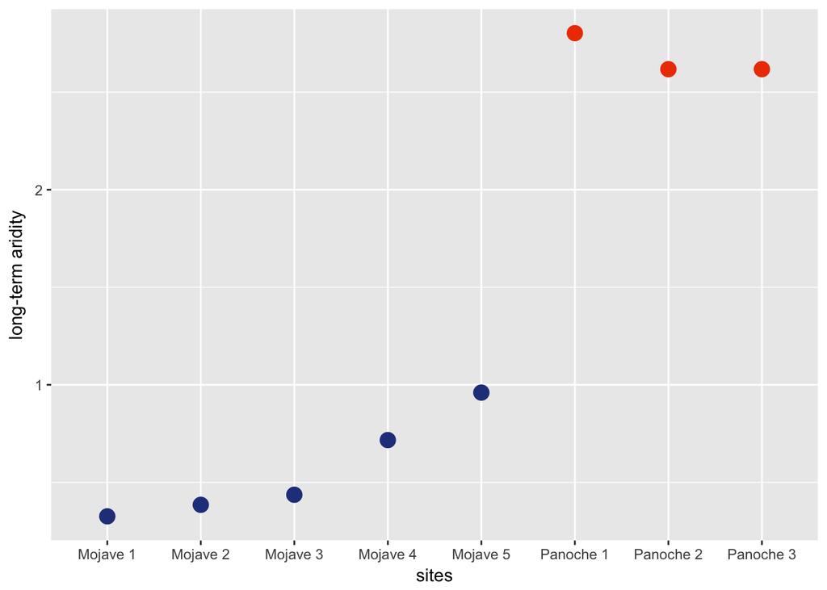

```r
ggplot(climate, aes(Site.name, Aridity, color = Region)) +
  geom_point(size = 4) +
  scale_color_manual(values = c("royalblue4", "orangered2")) +
  guides(color=FALSE) +
  scale_x_discrete(labels = c("Mojave 1", "Mojave 2", "Mojave 3", "Mojave 4", "Mojave 5", "Panoche 1", "Panoche 2", "Panoche 3")) + labs(x = "sites", y = "long-term aridity")
```

### Data viz

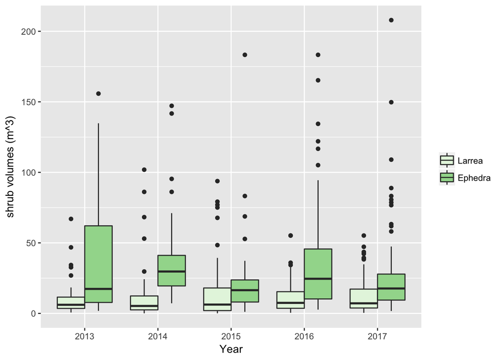

```r
#shrub sizes
ggplot(foundation.rii, aes(Year, Volume, fill = Region)) + geom_boxplot() + ylab("shrub volumes (m^3)") +
scale_fill_brewer(palette = "Greens", labels = c("Larrea", "Ephedra")) + theme(legend.title=element_blank())
```